# Lab2

Reesa John

1/26/2019

```r
avo <- read.csv("https://www.dropbox.com/s/vsc1dkosz6nwake/avocado.csv?dl=1")

## put this at the beginning of all your Rmarkdown projects:

library(tidyverse)
```

Preliminary Info: Product Lookup Code (PLU): (X)4046 - Total # of Small Hass #60 sizes and smaller sold (X)4225 - Total # of Large Hass #40 & #48 sizes sold (X)4770 - Total # of X-Large Hass #36 sizes and larger sold

X1 does not seem to be a meaningful variable

Exploring the dataset:

```r
avo <- avo %>% select(-X1)
summary(avo)
```

```
##          Date       AveragePrice    Total.Volume          X4046
##  2015-09-27:  50   Min.   :0.440   Min.   :     482   Min.   :       0
##  2016-05-15:  48   1st Qu.:1.100   1st Qu.:   10723   1st Qu.:     858
##  2016-08-21:  48   Median :1.370   Median :  102685   Median :    8263
##  2015-02-22:  46   Mean   :1.412   Mean   :  869558   Mean   :  298955
##  2017-07-23:  46   3rd Qu.:1.670   3rd Qu.:  435298   3rd Qu.:  112512
##  2017-10-22:  46   Max.   :3.250   Max.   :42939822   Max.   :16215329
##  (Other)   :5799
##      X4225              X4770             Total.Bags
##  Min.   :       0   Min.   :      0.0   Min.   :       0
##  1st Qu.:    2961   1st Qu.:      0.0   1st Qu.:    4950
##  Median :   27885   Median :    188.3   Median :   39476
##  Mean   :  302810   Mean   :  23719.1   Mean   :  244072
##  3rd Qu.:  150315   3rd Qu.:   6416.9   3rd Qu.:  110651
##  Max.   :16054084   Max.   :1896149.5   Max.   :15972492
##
##    Small.Bags         Large.Bags       XLarge.Bags
##  Min.   :       0   Min.   :      0   Min.   :     0.0
##  1st Qu.:    2805   1st Qu.:    135   1st Qu.:     0.0
##  Median :   24494   Median :   2682   Median :     0.0
##  Mean   :  185824   Mean   :  55036   Mean   :  3211.8
##  3rd Qu.:   82598   3rd Qu.:  23068   3rd Qu.:   130.3
##  Max.   :11712807   Max.   :3988102   Max.   :454343.7
##
##            type           year                    region
##  conventional:3006   Min.   :2015   Plains           : 134
##  organic     :3077   1st Qu.:2015   NewYork          : 126
##                      Median :2016   RaleighGreensboro: 125
##                      Mean   :2016   GreatLakes       : 124
##                      3rd Qu.:2017   Jacksonville     : 124
##                      Max.   :2018   Columbus         : 123
##                                     (Other)          :5327
```

1. Which region sold the most bags of small organic avocados in 2017? Hint: TotalUS does not count as a region!

The region that sold the most bags of small organic avocados in 2017 is the Northeast.

```r
avo %>%
  filter(region!="TotalUS",type =="organic", year ==2017)%>%
  top_n(1,Small.Bags)%>%
  select(region)
```

```
##      region
## 1 Northeast
```

2. Use separate() to split the Date variable into year, month, and day. In which month is the highest volume of avocado sales?

On average, January tends to sell the highest volume of avocadoes, though the highest monthly avocado sales in any year was in the March of 2018.

```r
tempAvo1 <-  avo %>%
  select(-year)%>%
  separate(Date,into = c("year","month","day"))%>%
  group_by(month,year)%>%
  summarize(monthlyVolume=sum(Total.Volume))

tempAvo1 %>%
  group_by(month)%>%
  summarize(averageMonthlyVolume = mean(monthlyVolume))%>%
  top_n(1,averageMonthlyVolume)
```

```
## # A tibble: 1 x 2
##   month averageMonthlyVolume
##   <chr>                <dbl>
## 1 01               160387581
```

```r
tempAvo1%>%
  unite("YearMonth", c(month,year), sep = "-")%>%
  top_n(1,monthlyVolume)
```

```
## # A tibble: 1 x 2
##   YearMonth monthlyVolume
##   <chr>             <dbl>
## 1 03-2018       229821321
```

3. Which regions sell the most avocados by volume? Plot side-by-side boxplots of Total Volume for only the 5 regions with the highest averages for the Total Volume variable. Hint: Once you narrow down to the top 5 regions, you can use pull() to save the vector of region names for later use.

The five regions that sell the most avocados are California, Northeast, South Central, Southeast, and the West, though not in that order necessarily.

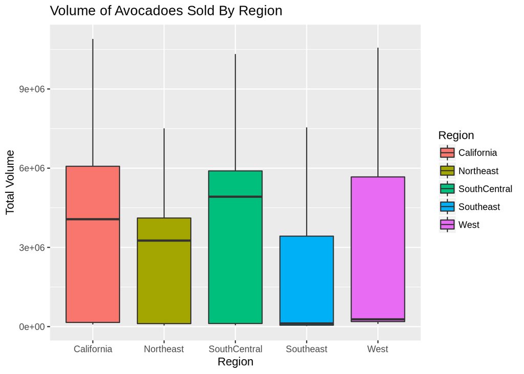

```r
top5 <- avo %>%
  filter(region!="TotalUS")%>%
  group_by(region)%>%
  summarize(averageMonthlyVolume = mean(Total.Volume))%>%
  top_n(5,averageMonthlyVolume) %>%
  arrange(desc(averageMonthlyVolume))%>%
  pull(region)



avo %>%
 filter(region %in% top5) %>%
 ggplot(aes(x = region, y = Total.Volume, fill=region)) +ggtitle("Volume of Avocadoes Sold By Region")+xlab("Region")+ylab("Total Volume")+labs(fill="Region")+
 geom_boxplot()
```

The following four California regions are in this dataset: LosAngeles, SanDiego, Sacramento, SanFrancisco. Answer the following questions about the California regions only. Hint: These questions will require restructuring of your data!

```r
CalRegions <- c("LosAngeles", "SanDiego","Sacramento","SanFrancisco")
CalRegions <- avo%>%
  filter(region %in% CalRegions)
```

4. In which regions is the price of organic versus conventional avocados most different? Support your answer with a few summary numbers and a plot.

Looking at the plot and table, San Francisco has the highest difference in average prices for organic vs conventional avocados at by around an 85 cents difference.

```r
diffByRegion <-  CalRegions %>%
  select(AveragePrice,type,region)%>%
  group_by(region,type)%>%
  summarize(price = mean(AveragePrice))%>%
  ungroup()%>%
  spread(type,price)%>%
  mutate("organicConventional" = organic-conventional)

diffByRegion %>% group_by(region)%>%summarize(organicConventional)
```

```
## # A tibble: 4 x 2
##   region       organicConventional
##   <fctr>                     <dbl>
## 1 LosAngeles                 0.502
## 2 Sacramento                 0.688
## 3 SanDiego                   0.685
## 4 SanFrancisco               0.850
```

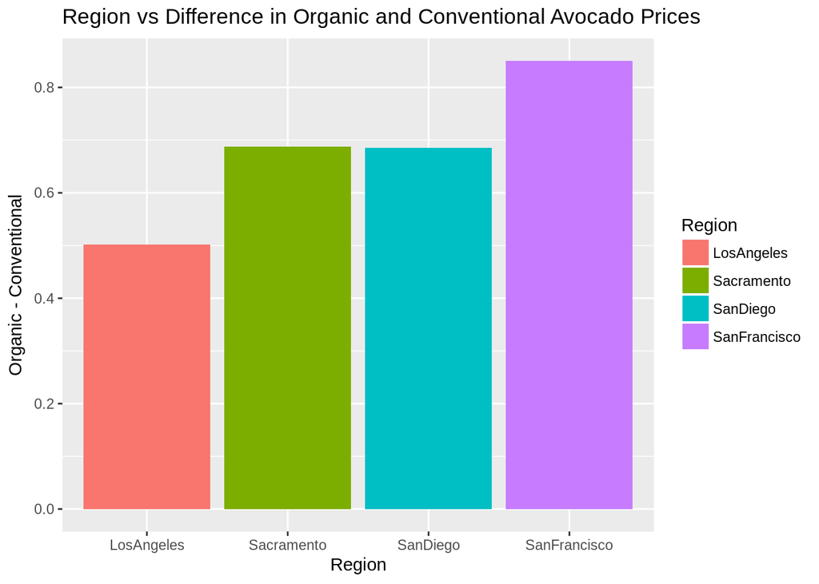

```r
diffByRegion%>%ggplot(aes(x=region,y=organicConventional,fill=region))+ggtitle("Region vs Difference in Organic and Conventional Avocado Prices")+xlab("Region")+ylab("Organic - Conventional")+labs(fill="Region")+
  geom_col()
```

5. How do their avocado habits differ? Make a plot that shows, for all 4 California regions, the percent of avocado sales that are small, large, or extra large. Separate your plot by conventional vs. organic

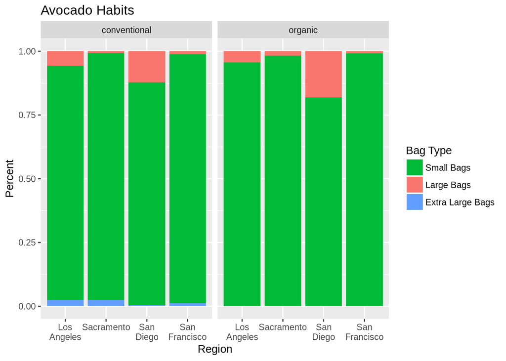

```r
avoHabits <- CalRegions %>%
  group_by(type,region)%>%
  select(region,type,Small.Bags,Large.Bags,XLarge.Bags,Total.Bags)%>%
  mutate(smallPct = Small.Bags/Total.Bags, largePct = Large.Bags/Total.Bags, xLargePct=XLarge.Bags/Total.Bags)%>%
  summarize_at(vars(smallPct,largePct,xLargePct,Total.Bags), funs(mean), na.rm = TRUE)%>%
  gather(key=typePct,percent,c("smallPct","largePct","xLargePct"))
avoHabits%>%
  ggplot(aes(x=region,y=percent,fill=typePct))+geom_col()+facet_grid(~type)+ggtitle("Avocado Habits")+
  xlab("Region")+ylab("Percent")+scale_fill_discrete(name="Bag Type",
                         breaks=c("smallPct","largePct","xLargePct"),
                         labels=c("Small Bags", "Large Bags", "Extra Large Bags"))+scale_x_discrete(labels = c("Los\nAngeles","Sacramento","San\nDiego","San\nFrancisco"))
```